# Measurement distributions and variability

Each participant-variable bucket with a non-missing mean counts as **one measurement**, whether it contains one or five observations. Missing means are excluded; GPS coordinates are included. Reader date defaults apply when loading.

## Total by variable

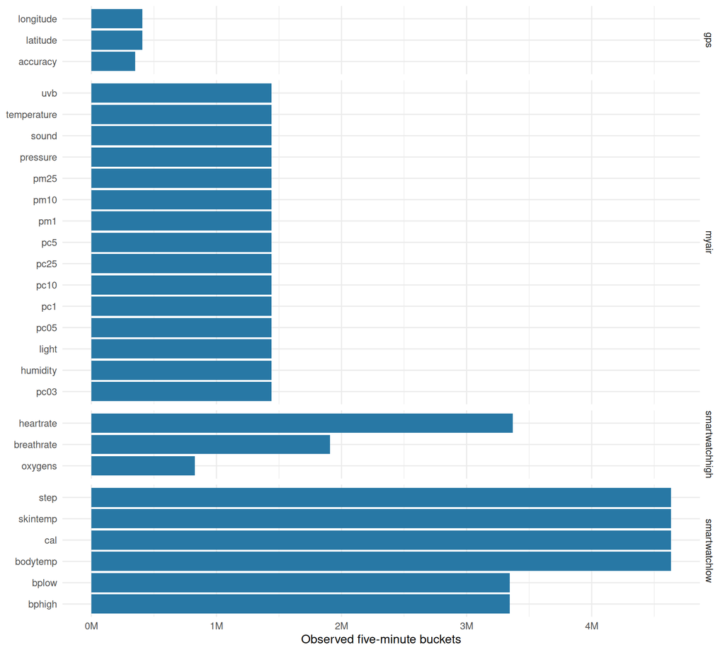

## Overview: original scale

All participants and dates are pooled. Each histogram uses the five-minute means, with one contribution per observed bucket and no weighting by `n`. Axes vary by variable; values retain their original units. No outlier thresholds are applied.

### myair

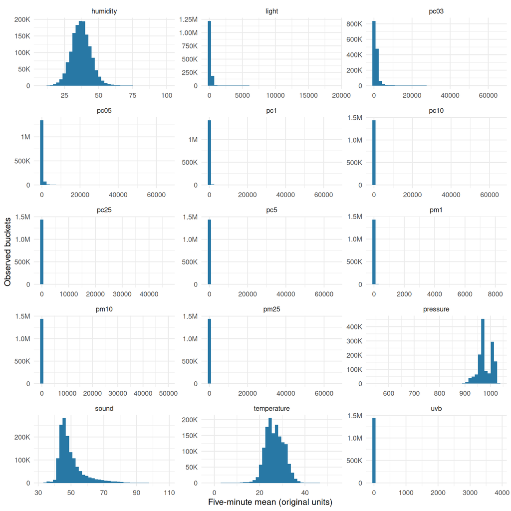

### smartwatchhigh

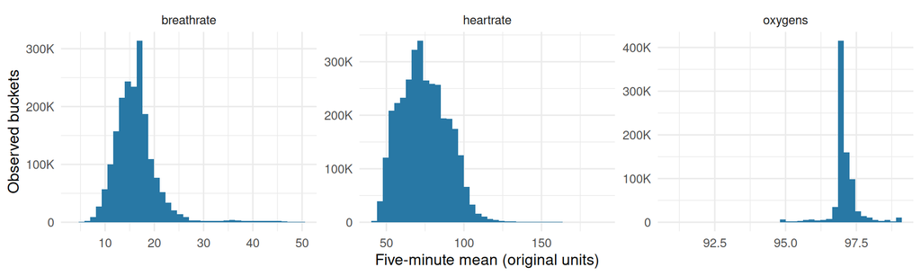

### smartwatchlow

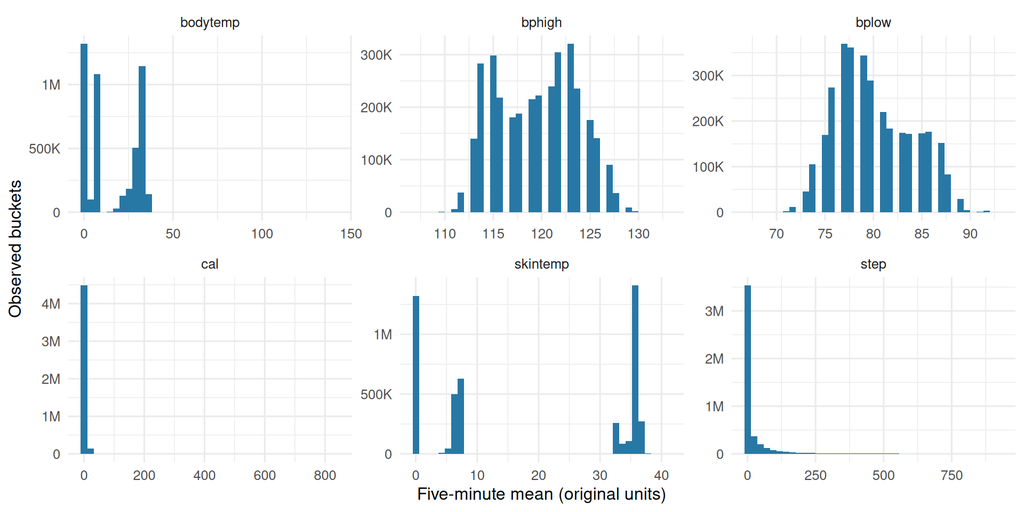

### gps

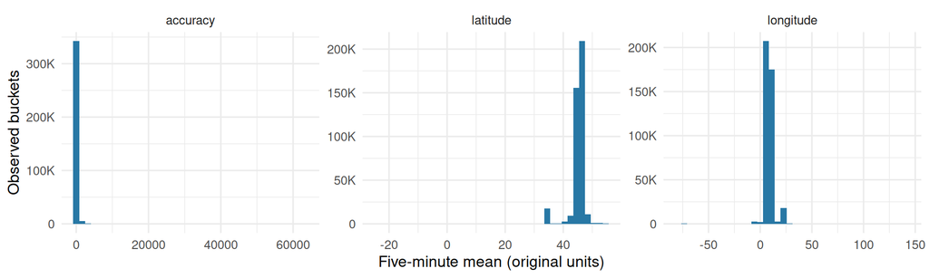

## Focused views

### Log scale

`uvb`, `light`, `pm*` and `pc*`: log(1 + x) scale, retaining zeros and extremes.

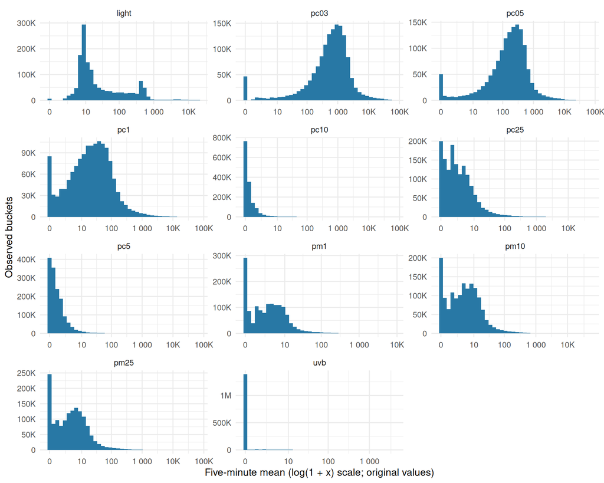

### Blood pressure

1 mmHg bins, retaining the full range.

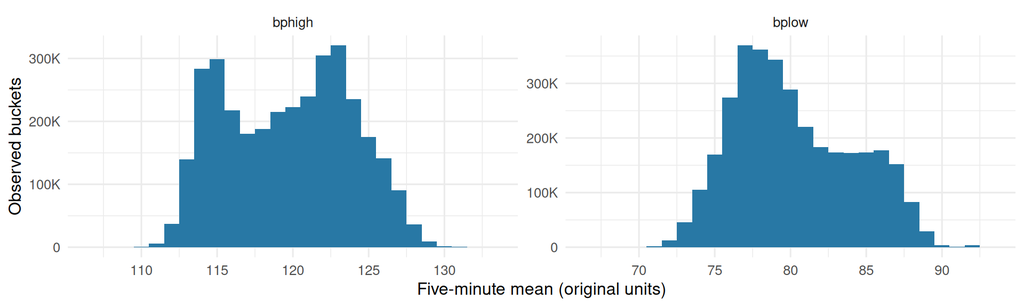

## Changes between consecutive buckets

`delta` is the current mean minus the previous mean for the same participant, source and variable. Only pairs exactly five minutes apart are included; missing means and longer gaps are excluded. Absolute changes describe transition size, in each variable’s original units, and cannot be ranked directly across units.

| origin | variable | pairs | median_abs | p95_abs |
| --- | --- | --- | --- | --- |
| gps | accuracy | 231175 | 0.00 | 160.00 |
| gps | latitude | 286763 | 0.00 | 0.01 |
| gps | longitude | 286763 | 0.00 | 0.01 |
| myair | humidity | 1429499 | 0.17 | 2.00 |
| myair | light | 1429499 | 0.20 | 138.80 |
| myair | pc03 | 1429301 | 36.60 | 453.60 |
| myair | pc05 | 1429499 | 10.60 | 128.80 |
| myair | pc1 | 1429499 | 3.20 | 33.60 |
| myair | pc10 | 1429499 | 0.20 | 1.20 |
| myair | pc25 | 1429499 | 0.80 | 6.00 |
| myair | pc5 | 1429499 | 0.40 | 2.40 |
| myair | pm1 | 1429499 | 0.20 | 2.80 |
| myair | pm10 | 1429499 | 0.50 | 5.20 |
| myair | pm25 | 1429499 | 0.40 | 4.60 |
| myair | pressure | 1429499 | 0.00 | 0.60 |
| myair | sound | 1429499 | 0.60 | 7.40 |
| myair | temperature | 1429499 | 0.04 | 0.80 |
| myair | uvb | 1429499 | 0.00 | 0.00 |
| smartwatchhigh | breathrate | 1891246 | 0.60 | 1.80 |
| smartwatchhigh | heartrate | 3305746 | 2.40 | 13.80 |
| smartwatchhigh | oxygens | 811415 | 0.20 | 1.20 |
| smartwatchlow | bodytemp | 4607756 | 0.00 | 1.00 |
| smartwatchlow | bphigh | 3285994 | 5.00 | 11.00 |
| smartwatchlow | bplow | 3285994 | 4.00 | 11.00 |
| smartwatchlow | cal | 4607756 | 0.00 | 6.00 |
| smartwatchlow | skintemp | 4607756 | 0.00 | 0.06 |
| smartwatchlow | step | 4607756 | 0.00 | 126.00 |

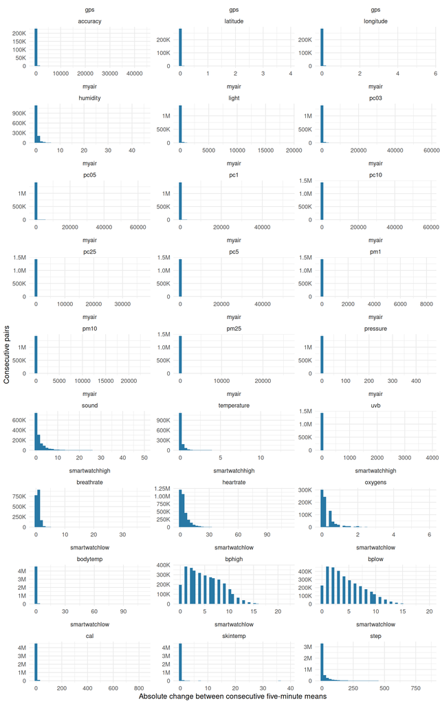

## Hourly difference

`max - min` within each participant-variable hour, in original units. Missing pairs are excluded; no minimum coverage threshold is applied.

| origin | variable | hours | median | p95 |
| --- | --- | --- | --- | --- |
| gps | accuracy | 55452 | 25.00 | 595.45 |
| gps | latitude | 63957 | 0.00 | 0.05 |
| gps | longitude | 63957 | 0.00 | 0.07 |
| myair | humidity | 128436 | 1.94 | 14.97 |
| myair | light | 128436 | 7.00 | 3445.00 |
| myair | pc03 | 128432 | 450.00 | 5420.70 |
| myair | pc05 | 128436 | 130.00 | 1543.25 |
| myair | pc1 | 128436 | 42.00 | 410.00 |
| myair | pc10 | 128436 | 2.00 | 10.00 |
| myair | pc25 | 128436 | 8.00 | 62.00 |
| myair | pc5 | 128436 | 4.00 | 18.00 |
| myair | pm1 | 128436 | 3.00 | 32.00 |
| myair | pm10 | 128436 | 6.00 | 65.00 |
| myair | pm25 | 128436 | 5.00 | 56.00 |
| myair | pressure | 128436 | 0.00 | 4.00 |
| myair | sound | 128436 | 12.00 | 40.00 |
| myair | temperature | 128436 | 0.62 | 5.45 |
| myair | uvb | 128436 | 0.00 | 2.00 |
| smartwatchhigh | breathrate | 166868 | 4.00 | 9.00 |
| smartwatchhigh | heartrate | 299309 | 30.00 | 57.00 |
| smartwatchhigh | oxygens | 81183 | 2.00 | 4.00 |
| smartwatchlow | bodytemp | 392266 | 1.00 | 36.70 |
| smartwatchlow | bphigh | 297083 | 12.00 | 15.00 |
| smartwatchlow | bplow | 297083 | 12.00 | 15.00 |
| smartwatchlow | cal | 392266 | 1.00 | 22.00 |
| smartwatchlow | skintemp | 392266 | 0.00 | 36.50 |
| smartwatchlow | step | 392266 | 20.00 | 437.00 |

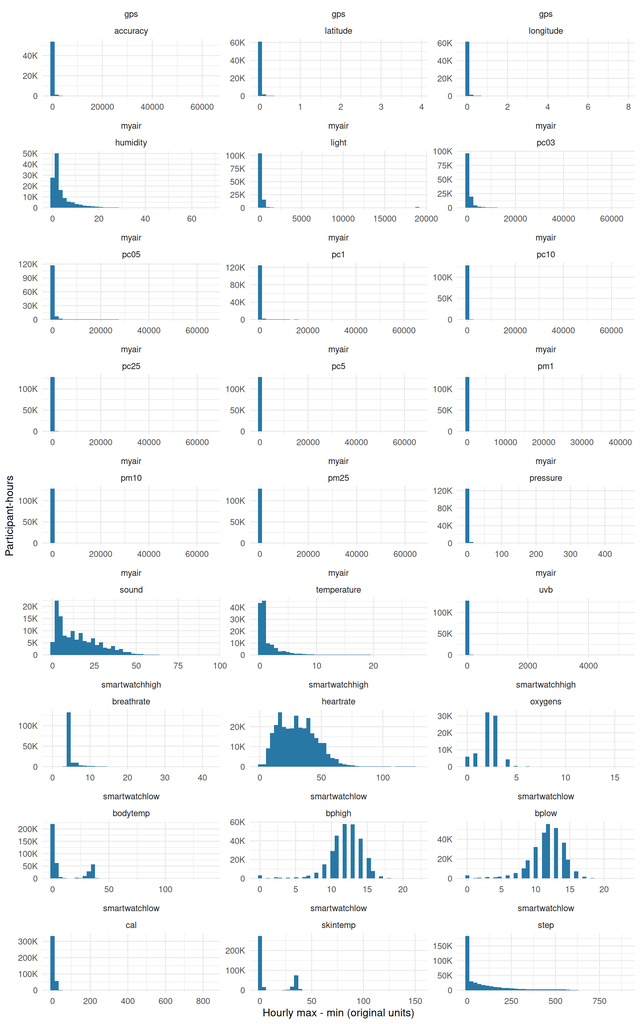

## Daily difference

`max - min` within each participant-variable day. Minimum and maximum are paired by source, participant, date and variable. Sleep and missing pairs are excluded; no minimum coverage threshold is applied. Daily and hourly differences describe ranges within different window lengths, not transitions between windows.

| origin | variable | days | median | p95 |
| --- | --- | --- | --- | --- |
| gps | accuracy | 6864 | 89.00 | 1899.00 |
| gps | latitude | 9730 | 0.00 | 0.33 |
| gps | longitude | 9730 | 0.00 | 0.45 |
| myair | humidity | 9886 | 15.19 | 38.29 |
| myair | light | 9886 | 446.00 | 18897.00 |
| myair | pc03 | 9885 | 2238.00 | 39593.40 |
| myair | pc05 | 9886 | 639.50 | 12142.50 |
| myair | pc1 | 9886 | 161.00 | 3776.50 |
| myair | pc10 | 9886 | 4.00 | 39.00 |
| myair | pc25 | 9886 | 24.00 | 490.75 |
| myair | pc5 | 9886 | 8.00 | 101.75 |
| myair | pm1 | 9886 | 13.00 | 243.75 |
| myair | pm10 | 9886 | 25.00 | 562.00 |
| myair | pm25 | 9886 | 22.00 | 487.75 |
| myair | pressure | 9886 | 4.00 | 43.00 |
| myair | sound | 9886 | 34.00 | 55.00 |
| myair | temperature | 9886 | 6.00 | 15.84 |
| myair | uvb | 9886 | 0.00 | 29.00 |
| smartwatchhigh | breathrate | 8881 | 11.00 | 33.00 |
| smartwatchhigh | heartrate | 16452 | 67.00 | 106.45 |
| smartwatchhigh | oxygens | 12234 | 3.00 | 5.00 |
| smartwatchlow | bodytemp | 17436 | 28.15 | 37.50 |
| smartwatchlow | bphigh | 16311 | 17.00 | 19.00 |
| smartwatchlow | bplow | 16311 | 17.00 | 18.00 |
| smartwatchlow | cal | 17436 | 22.00 | 34.00 |
| smartwatchlow | skintemp | 17436 | 31.20 | 37.50 |
| smartwatchlow | step | 17436 | 432.00 | 592.00 |

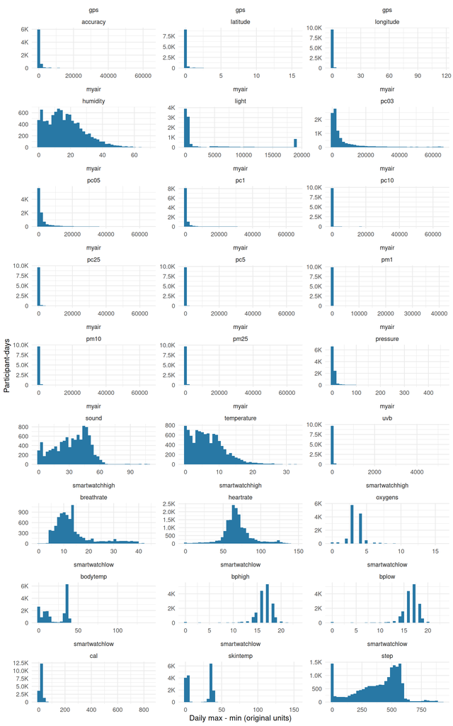